# Data Wrangling and Visualization

## 10.1 Scatterplot of vegetable and fruits variable by gender

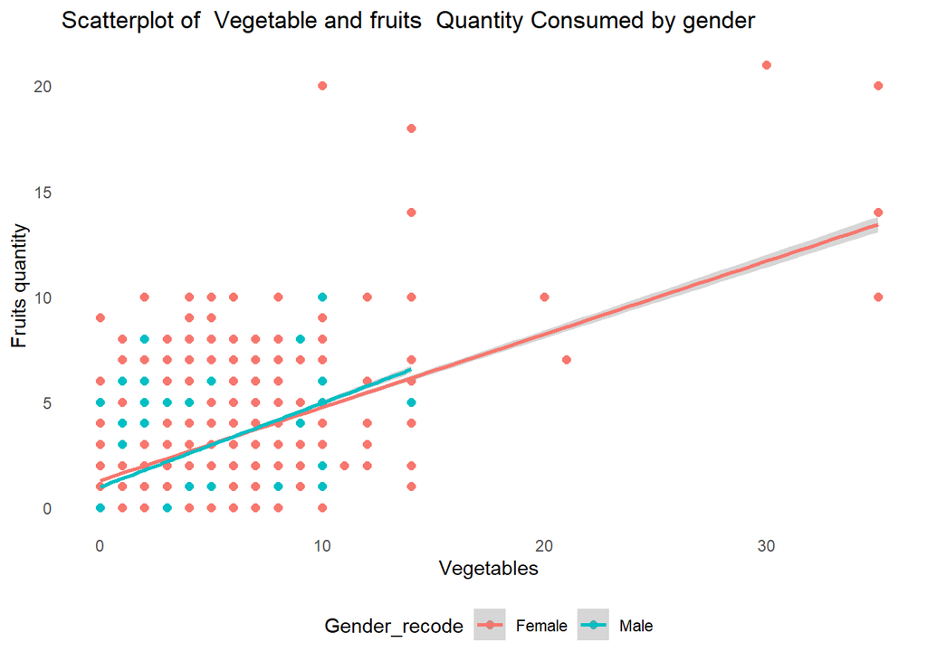

```r
ggplot(can_path_merged, aes(Veg_qty,Fruits_qty, colour = Gender_recode))+
  geom_point(size = 2)+
  geom_smooth( method = "lm")+
  labs(title = "Scatterplot of  Vegetable and fruits  Quantity Consumed by gender", x = 'Vegetables',
       y = "Fruits quantity")+
  theme_minimal()+
  theme(
  legend.position = 'bottom'
  )+
  theme(panel.grid.major = element_blank(), panel.grid.minor = element_blank())
```

From the scatter plot, it can be observed that a moderate positive correlation exist between fruits quantity consumed and vegetables, however, extreme outlier were seen among females compared to males.

## 10.2 Scatterplot of vegetable and fruits variable by Income

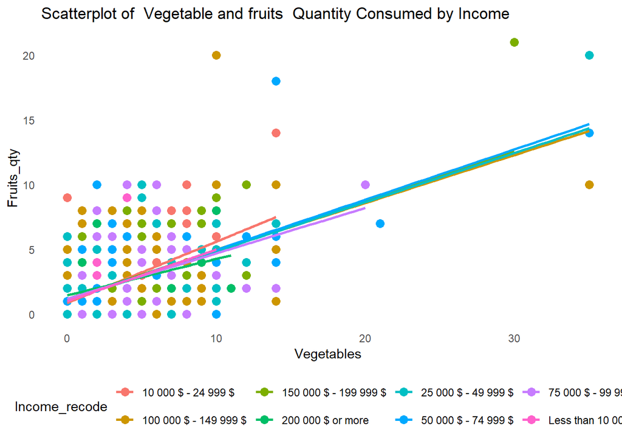

```r
ggplot(can_path_merged, aes(Veg_qty,Fruits_qty, colour = Income_recode))+
  geom_point(size = 3)+
  geom_smooth(method = "lm", se = FALSE)+
  labs(title = "Scatterplot of  Vegetable and fruits  Quantity Consumed by Income", x = 'Vegetables')+
  theme_minimal()+
  theme(
  legend.position = 'bottom'
  )+
  theme(panel.grid.major = element_blank(), panel.grid.minor = element_blank())
```

A positive corelation can be observed however, income variables are dispersed randomly on the scatter plot without any observable patterns.

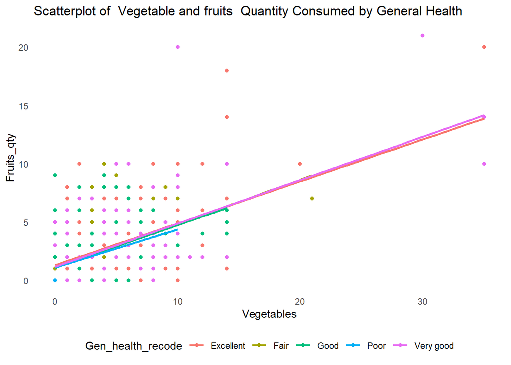

```r
ggplot(can_path_merged, aes(Veg_qty,Fruits_qty, colour = Gen_health_recode))+
  geom_point()+
  geom_smooth( method = "lm", se = FALSE)+
  labs(title = "Scatterplot of  Vegetable and fruits  Quantity Consumed by General Health", x = 'Vegetables')+
  theme_minimal()+
  theme(
  legend.position = 'bottom'
  )+
  theme(panel.grid.major = element_blank(), panel.grid.minor = element_blank())
```

A psoitive correlation can be observed in the scatter plot above, however, extreme vegetable consumtion were seen among those who responded having excellent health and very good respectively.

## 10.4 Scatterplot of vegetable and fruits variable by Asthma Status

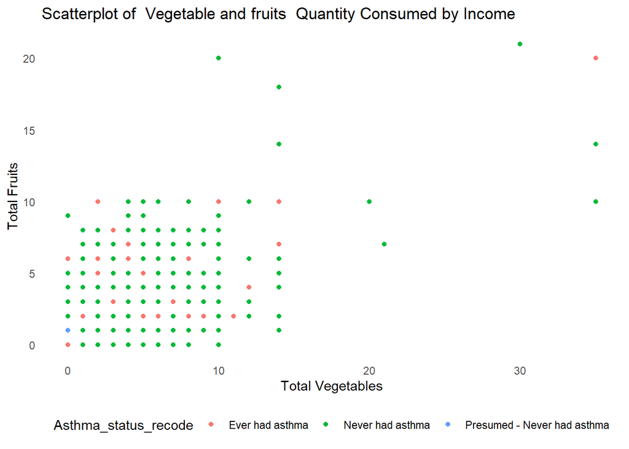

```r
ggplot(can_path_merged, aes(Veg_qty,Fruits_qty, colour = Asthma_status_recode))+
  geom_point()+
  labs(title = "Scatterplot of  Vegetable and fruits  Quantity Consumed by Income", x = 'Total Vegetables',
       y = "Total Fruits ")+
  theme_minimal()+
  theme(
  legend.position = 'bottom'
  )+
  theme(panel.grid.major = element_blank(), panel.grid.minor = element_blank())
```

A moderate correlation can be seen between, total fruits and vegetables quantity, extreme vegetables and fruits were seen disporportionately among those who have never had asthma.

## 10.5 Scatterplot ot total fruits_vegetable and physical activity short

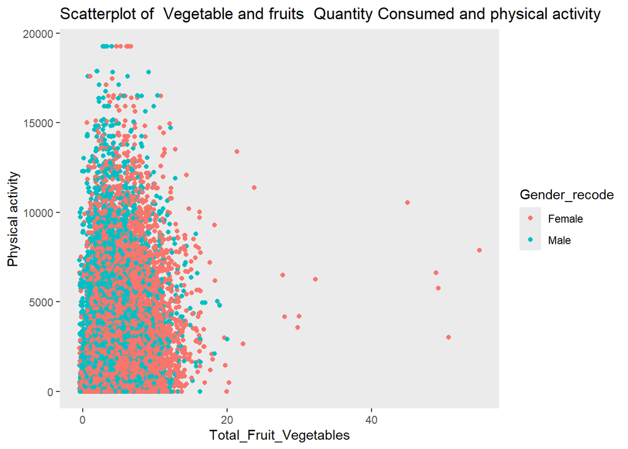

```r
ggplot(can_path_merged, aes(Tot_fruit_veg,PA_total_short, colour = Gender_recode))+
  geom_point(position ="Jitter")+
  labs(title = "Scatterplot of  Vegetable and fruits  Quantity Consumed and physical activity", x = 'Total_Fruit_Vegetables',
       y = "Physical activity")+
  theme(panel.grid.major = element_blank(), panel.grid.minor = element_blank())
```

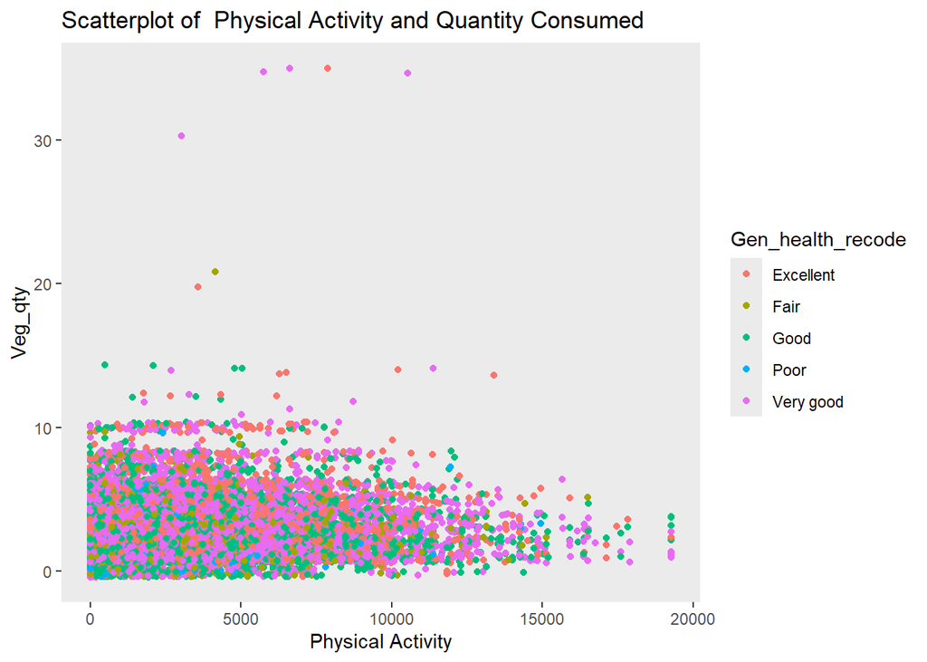

```r
ggplot(can_path_merged, aes(PA_total_short, Veg_qty, colour = Gen_health_recode))+
  geom_point(position = 'jitter')+
  labs(title = "Scatterplot of  Physical Activity and Quantity Consumed", x = 'Physical Activity')+
  theme(panel.grid.major = element_blank(), panel.grid.minor = element_blank())
```

A weak positive correlation can be seen between vegetable quantity and physical activity. However, extreme vegetable consumption was seen among those with excellent and very good health status

# **11 Correlation matrix for all numeric variables**

```r
corr_matrix <- can_path_merged %>%
  select(Veg_qty, Fruits_qty, Tot_fruit_veg, PA_total_short) %>%
  cor(use = "complete.obs")

corr_matrix
```

```
##                   Veg_qty Fruits_qty Tot_fruit_veg PA_total_short
## Veg_qty        1.00000000  0.4486267     0.8791746     0.09483531
## Fruits_qty     0.44862673  1.0000000     0.8202782     0.10024328
## Tot_fruit_veg  0.87917461  0.8202782     1.0000000     0.11413915
## PA_total_short 0.09483531  0.1002433     0.1141391     1.00000000
```

The correlation matrix above presents the correlation between the numeric variables. The correlation between vegetable and fruit consumption is moderate and positive, 0.45, reflecting a general relationship but not perfect. Total fruit/vegetable consumption strongly correlates with both vegetable intake and fruit intake, 0.88 and 0.82, respectively, showing tight clusters.This can also be explained by deriving the total vegetable and fruits from the vegetable and fruits variable creating correlating values. Physical activity correlates weakly with food variables, 0.09–0.11, reflecting a minimum relationship or pattern.

## 11.1 Heatmap of numeric variables

```r
melted_corr <- melt(corr_matrix)

melted_corr
```

```
##              Var1           Var2      value
## 1         Veg_qty        Veg_qty 1.00000000
## 2      Fruits_qty        Veg_qty 0.44862673
## 3   Tot_fruit_veg        Veg_qty 0.87917461
## 4  PA_total_short        Veg_qty 0.09483531
## 5         Veg_qty     Fruits_qty 0.44862673
## 6      Fruits_qty     Fruits_qty 1.00000000
## 7   Tot_fruit_veg     Fruits_qty 0.82027822
## 8  PA_total_short     Fruits_qty 0.10024328
## 9         Veg_qty  Tot_fruit_veg 0.87917461
## 10     Fruits_qty  Tot_fruit_veg 0.82027822
## 11  Tot_fruit_veg  Tot_fruit_veg 1.00000000
## 12 PA_total_short  Tot_fruit_veg 0.11413915
## 13        Veg_qty PA_total_short 0.09483531
## 14     Fruits_qty PA_total_short 0.10024328
## 15  Tot_fruit_veg PA_total_short 0.11413915
## 16 PA_total_short PA_total_short 1.00000000
```

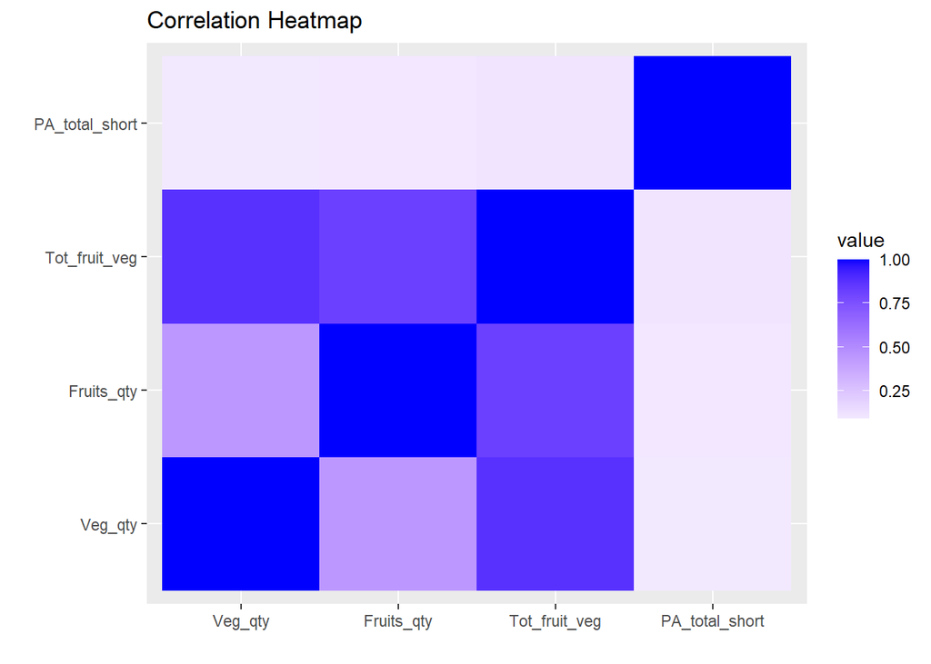

```r
ggplot(melted_corr, aes(x = Var1, y = Var2, fill = value)) +
    geom_tile() +
    scale_fill_gradient2(low = "red", high = "blue", mid = "white", midpoint = 0) +
    labs(title = "Correlation Heatmap", x = "", y = "")
```

The heatmap shows strong correlations between vegetable and total fruit/vegetable intake (0.88) and fruit and total fruit/vegetable intake (0.82). Vegetable and fruit intake have a moderate correlation (0.45). Physical activity weakly correlates with all dietary variables (0.09–0.11), indicating minimal connection between physical activity levels and food consumption patterns.